# Final Paper

STOR 320.(02) Group 6

April 25, 2020

# INTRODUCTION

Following the initial meeting and introduction of the project, Group 6 members perused the vast libraries of datasets online and happened across a particularly large dataset via data.world containing a complete profile of loans issued by the company LendingClub (LC). LendingClub is the first largest peer-to-peer platform for facilitating lending and borrowing of loans from $1000 to 35000. LC hit the highest IPO in the tech sector in 2014. Our group found the prospect of evaluating credit for investments and loan issuing particularly interesting and useful for future applications in risk analysis and creating realistic recommendations for potential investors.

The initial questions that Group 6 posed were, unfortunately, not thorough enough to create substantial predictive models. One of the questions Group 6 initially posed but didn’t expand on during the EDA phase of the project was “Can we predict whether an investor is able to pay a loan in full or if the account becomes delinquent?” A loan is considered delinquent the first day after a payment is missed, and the account remains delinquent until the past due amount is paid in full. This is one of the largest factors in credit risk: the investors ability to repay principal loans or interests. It is, of course, in the investor’s best interest to be able to repay a loan on time to avoid an on-record delinquency and higher interest rates. The lending company will also seek clients with a good credit history, and issue loans with lower interest rates to maintain an investor for the duration of the loan term. Thus, I went rogue and decided to tackle this question in my independent final analysis.

By recommendation of Dr. Mario, the second question I wanted to explore was “Can we predict the loan amount an investor will be issued?” This question aims to explore the factors that most significantly influence an individual’s line of credit and ability to be issued a loan. Moreover, since peer to peer lending is highly risky in terms of unsecured loans and high probability of investors defaulting, it would be interesting to determine if the amount a borrower is able to obtain from an unsecured loan could even be determined by factors including a person’s past spending habits, income, and past credit managing behavior.

Through the exploration and analysis of these two questions, my aim to create a preliminary risk assessment of borrowers in the peer-to-peer lending industry and make recommendations to LC based on volatility of investor habits and potential loss the company could face by issuing loans to people unable to pay back full amount plus interest. This is likely pretty dry information to most millennials and young adults, but building good credit starts now, especially for those with some student loan debt. If you are ever considering opening a credit card account or taking out a loan on a mortgage, these results might interest you.

# DATA

The dataset we chose was found on data.world, uploaded by user lpetrocelli, but the source originated from the LendingClub official website, available as an downloadable file of loan data issued in the first quarter of 2017. The dataset contains over 96000 observations from customers who were issued loans from January to March of 2017, and 120 different variables related to each investor. Our group considered this a valuable dataset thorough enough create a predictive model for the questions proposed.

One important variable is the record of delinquencies within the last two years (delinq_2yrs), which indicates the number of 30+ day past-due incidents borrowers have had in the past 2 years. Once an overdue payment is recorded, it remains on an individual’s credit history for up to 7 years, and is generally a good indicator of a borrower’s ability to make payments on a loan on time. For most lending companies, generally the less delinquencies on a customer’s credit history the more likely they are to get a better loan. The purpose and status of home ownership (home_ownership) variables appeared to be valuable as well, as with a quick bar plot gives us a good indicator of the general demographic of individuals being issued loans from LC.

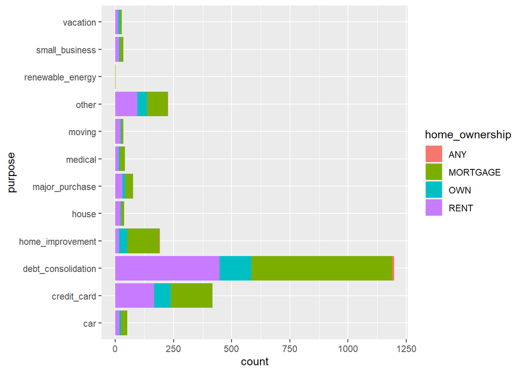

“Debt to Income Ratio” (dti) is a ratio that calculates the total monthly debt payments divided of a lender by his or her gross monthly income. It is another useful indication of an individual’s ability to manage monthly payments and repay debts, and is typically used by mortgage lenders. Generally, 43% is the highest DTI ratio a borrower can have and still be qualified for a mortgage. However, there are values within the dataset well above 1000 and in the negatives, but we will still consider the dataset valuable to account for possible events such as winning the lottery or unreported annual income that are realistic to daily life.

Other important variables, some of which were used to determine the loan amount an investor will be issued, were “Interest Rate” (int_rate), “Annual Income” (annual_inc), “Number of Inquiries in the last 6 months” (inq_last_6mths) and “Number of Open Credit Lines in a Borrower’s Credit File” (open_acc). If we can somehow create a relationship between these parameters as an indicator of credit score or liability to make payments on a loan, we will be able to better understand what qualifies a borrower for a loan and the risks assessed by lending companies whenever they issue loans.

The following is a representation of the most important variables provided in our data.

|  | loan_amnt | term | int_rate | purpose | home_ownership | annual_inc | dti | delinq_2yrs | open_acc | inq_last_6mths | dti2 | employ | status |
| --- | --- | --- | --- | --- | --- | --- | --- | --- | --- | --- | --- | --- | --- |
| 125 | 5000 | 36 months | 14.99 | home_improvement | OWN | 60000 | 13.32 | 0 | 5 | 0 | 13.32 | 2-4 years | Fully Paid |
| 713 | 25000 | 60 months | 18.99 | medical | MORTGAGE | 80000 | 8.07 | 0 | 11 | 1 | 8.07 | 2-4 years | Fully Paid |
| 822 | 29225 | 36 months | 18.99 | car | RENT | 85000 | 0.35 | 0 | 3 | 0 | 0.35 | 10+ years | Fully Paid |
| 1184 | 18000 | 36 months | 7.49 | debt_consolidation | MORTGAGE | 107000 | 12.09 | 0 | 14 | 0 | 12.09 | 2-4 years | Fully Paid |
| 1395 | 7200 | 36 months | 12.74 | other | MORTGAGE | 73000 | 12.05 | 0 | 7 | 0 | 12.05 | 10+ years | Fully Paid |
| 1430 | 4825 | 36 months | 11.44 | car | MORTGAGE | 42000 | 7.80 | 0 | 6 | 0 | 7.80 | 5-9 years | Fully Paid |

# RESULTS

To answer the first question predicting the ratio of delinquent accounts in a given quarter, I had to select and clean the most valuable parameters to my investigation. For the sake of simplifying the data, I decided to select only the variables that seemed to influence credit score most (indicated by the graphic given by vantagescore.com https://www.vantagescore.com/pdf/VantageScore%20Infographic%2005.pdf). In addition, I cleaned the loan status parameter to only contain loans that were either “Fully Paid” or “Delinquent”. I omitted loans that were current or loans that were late but within the 15-day grace period, as these loans have not matured and thus would add another level of unpredictability to the model. I decided the leave dti2 within its current range of 0.13 up to 84.03, to account for the possibility of unaccounted debt payments at the time of the request. This brought the dataset down to a size of 2300 observations from the initial 96000.

Then, the data was split into “train” and “test” data sets. 80% of the cleaned data was assigned the training set, and the remaining 20% assigned the test set. Then, I implemented a random forest model to predict occurrences of delinquencies. The parameters annual income, home ownership status, interest rate, employment status, debt to income ratio, term of the loan, and delinquencies were used as predictors. MeanDecreaseAccuracy is a measure of how much a variable improves the accuracy of the forest in predicting the categorical outcome. The higher the variable, the more it improves the prediction. From the plot, annual income is clearly the most important variable, although the value itself is quite low. From the MeanDecreaseGini, another measure of importance of factors to the accuracy of the model, debt to income ratio, annual income, and interest rate indicate that these are the most important predictors.

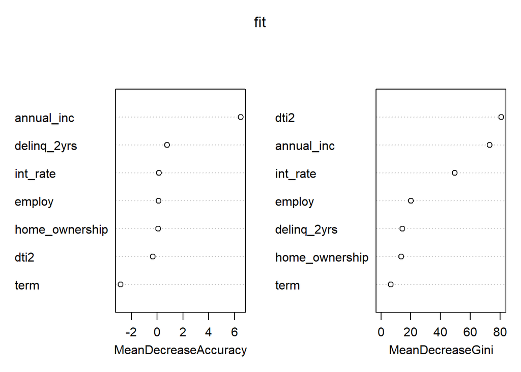

```
##
##       0   1   2   3   4   5   6   7
##   0 351  64  13   6   2   1   1   1
##   1   1   0   0   0   0   0   0   0
```

```
## [1] "Correctly Predicted: 84.38%"
```

The success of the random forest model is determined by the percentage of correct predictions over the category with the highest frequency, in this case being the indicator “Fully Paid”. According to our initial cleaning of the data, 2128 observations of the 2340 are “Fully Paid”, or 90.94% of loans were recorded as fully paid off. For the model to be a success, the percentages of cases predicted correctly should be higher than 90.94%. According the prediction model, 84.38% of observations were correctly predicted as “Fully Paid”, which is about 6.56% less than the actual ratio.

To further investigate this question, I implemented the k-Nearest Neighbors (k-NN) Technique to cross-validate the prediction on the two possible outcomes of loans. For this model, I wanted to see if delinquency and debt to income ratio were as invaluable as I initially expected, then used k-NN to predict a loan to be fully paid off or become delinquent. Again, splitting the data into test and train subsets, with 80% of the dataset to train the model. Then, I evaluated the model by cross tabulating predictions against the actual class of loan status in the test data set. The model correctly classified 421 loans as “Fully Paid” out of 470, giving us a percentage of 89.6%. This is about 1.3% less than the actual ratio from the dataset, which although still less than the actual percentage is still better than the random forest model. Our total accuracy is around 89.8%.

```
##
## Fully Paid Delinquent
##       2128        212
```

```
##
## Fully Paid Delinquent
## 0.91069519 0.08930481
```

```
## [1] Fully Paid Fully Paid Fully Paid Fully Paid Fully Paid Fully Paid
## Levels: Fully Paid Delinquent
```

```
##    Cell Contents
## |-------------------------|
## |                   Count |
## |           Total Percent |
## |-------------------------|
##
## ==============================================
##                pred
## test$status    Fully Paid   Delinquent   Total
## ----------------------------------------------
## Fully Paid           421            4     425
##                     89.6%         0.9%
## ----------------------------------------------
## Delinquent            44            1      45
##                      9.4%         0.2%
## ----------------------------------------------
## Total                465            5     470
## ==============================================
```

These results were rather interesting, as I originally thought record of past delinquencies and debt to income ratio significant predictors of future delinquent loans. This shows that LC has a pretty good ratio of fully paid loans to delinquencies, and if otherwise would mean that LC has highly risky investors and a high probability of experiencing loss within each quarter.

```
##
## Call:
## lm(formula = loan_amnt ~ annual_inc + int_rate + open_acc + factor(term) +
##     delinq_2yrs + inq_last_6mths, data = loan2)
##
## Residuals:
##    Min     1Q Median     3Q    Max
## -44109  -5832  -1509   4571  28349
##
## Coefficients:
##                          Estimate Std. Error t value Pr(>|t|)
## (Intercept)             1.781e+03  6.238e+02   2.855  0.00435 **
## annual_inc              6.419e-02  3.116e-03  20.600  < 2e-16 ***
## int_rate                2.603e+02  3.245e+01   8.021 1.65e-15 ***
## open_acc                1.566e+02  2.884e+01   5.430 6.21e-08 ***
## factor(term) 60 months  6.536e+03  4.391e+02  14.884  < 2e-16 ***
## delinq_2yrs            -3.990e+02  2.200e+02  -1.814  0.06979 .
## inq_last_6mths         -5.613e+02  1.953e+02  -2.874  0.00409 **
## ---
## Signif. codes:  0 '***' 0.001 '**' 0.01 '*' 0.05 '.' 0.1 ' ' 1
##
## Residual standard error: 8132 on 2333 degrees of freedom
## Multiple R-squared:  0.3039, Adjusted R-squared:  0.3021
## F-statistic: 169.8 on 6 and 2333 DF,  p-value: < 2.2e-16
```

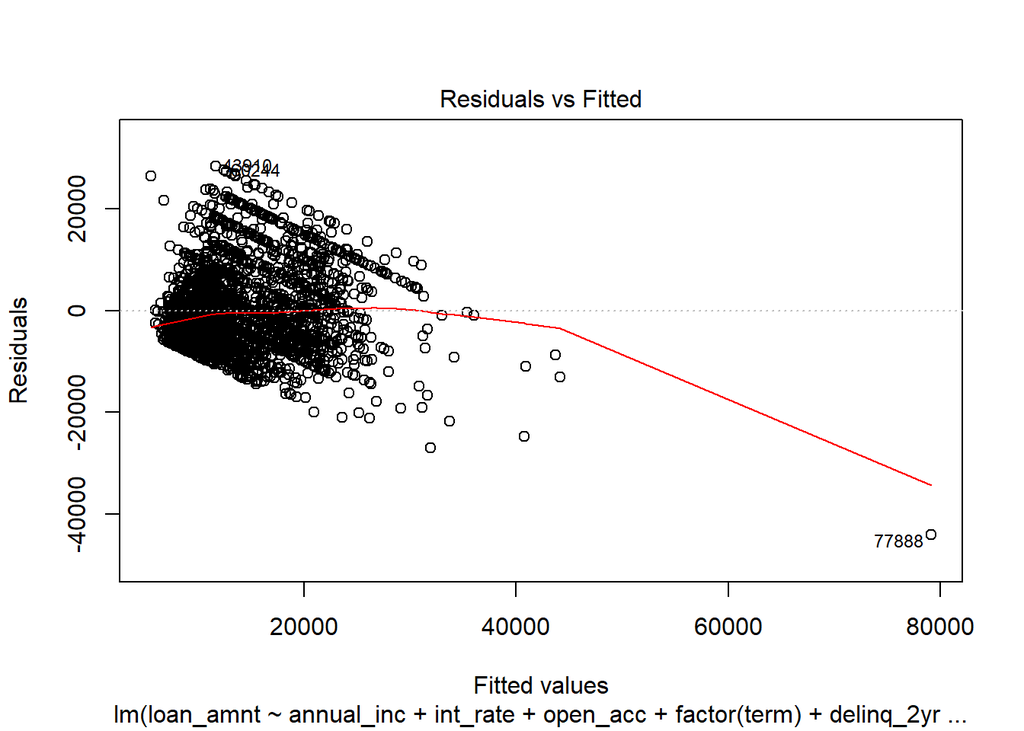

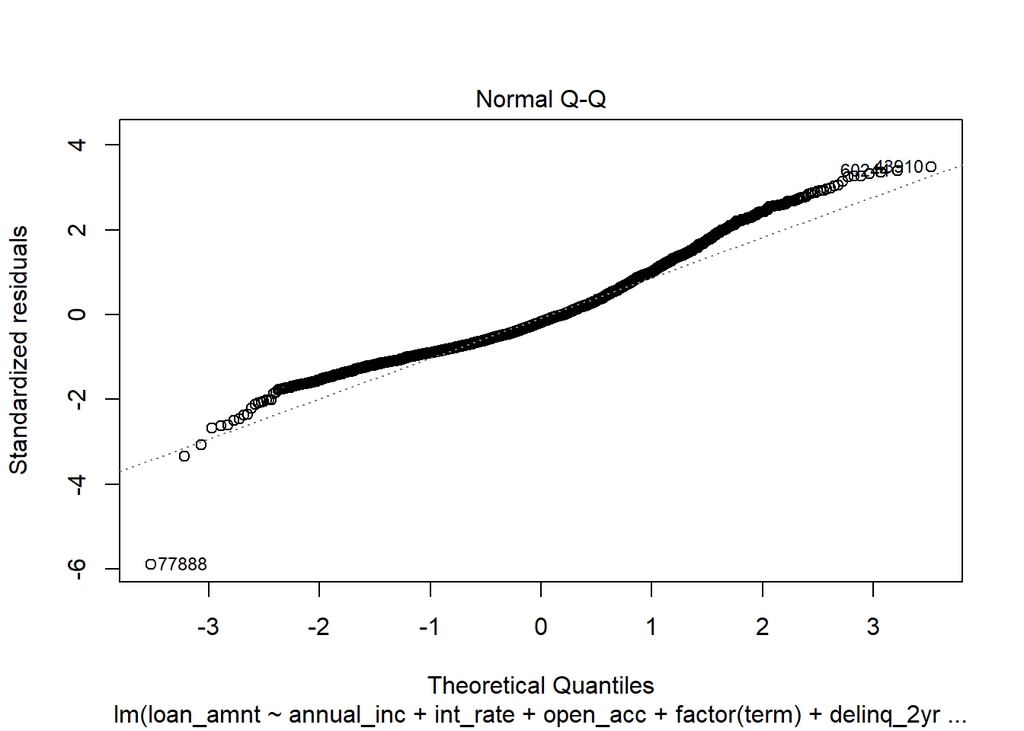

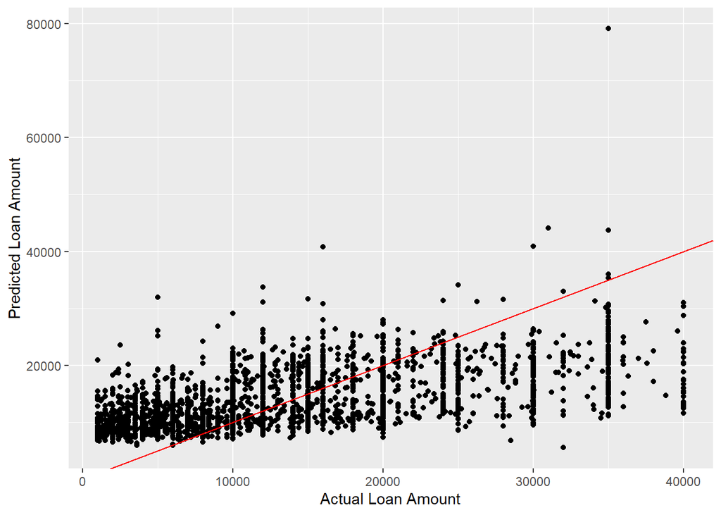

From this predictive model, I performed a diagnosis of the linear model by plotting diagnostic plots with the built-in R-function plot(). I looked the Residuals vs Fitted plot, which is an indicator of any patterns the residuals may have. The plot looks good util it passes the fitted values at 40,000, where there exists an extreme outlier number 77888. If we look at all the residuals before that point, however, there doesn’t appear to be any distinctive pattern or relationship in the model, which is a good indication that we have a linear relationship. Next, I looked at the Normal Q-Q plot, which depicts the distributions of the residuals. Again, safe for the extreme outliers, the residuals look relatively well aligned on the dashed line.

```
## [1] 8119.342
```

For the predictive plot itself, the linear model we created appears to be more conservative with respect to the loan amounts it predicted, with expected values well below actual values as the loan amounts increased. From the appearance of the models, it is clear there are some predictive issues with the model, especially with the low coefficient of determination from our linear model and lack of normalcy in the distribution of loan amounts from the data. I will talk about this in more detail in the conclusions.

# CONCLUSION

In our first question, we wanted to predict the number of fully paid and delinquent accounts using debt and income ratio and the borrower’s record of past delinquencies. From the random forest model and k-NN Technique, our model was slightly off from the actual ratio of fully paid to delinquent accounts, but had pretty high accuracy’s of around 84 and 90 percent. I was expecting the model to accurately predict the status of matured loans given the significance of the predictors DTI and delinquent accounts, so I was surprised to see that debt to income ratio did nothing to improve the accuracy of the random forest model. However, I was still pleased to see that the relative accuracy and predicted status of issued loans were quite accurate. Especially since lending companies deal with such a volatile industry with many factors influencing the qualifications of borrowers for loans, the fact that the model was able to predict the number of fully paid loans would be highly beneficial to lending companies seeking to minimize losses in a given quarter and maximize returns from their investors.

For the second question, we looked to predict the amount of loan that a qualified investor could be issued and give a general distribution for a given quarter. I found the most significant model was a multiple linear regression predicting loan_amnt as a function of annual_inc + int_rate + open_acc + factor(term) + delinq_2yrs + inq_last_6mths with an R-squared of 0.3021 and an RMSE of 8119.342. While these results are not impressive, with the exception of extreme outliers the linear regression model appeared to be a good fit for the data, justified by the diagnostic plots. Even with cleaning the data and removing some extreme outliers, there appeared to be too much variation in the loan_amnt to be able to create a completely accurate and comprehensive model without any misleading parameters. If this model were to be explored further in the future with a more extensive and meaningful set of variables, it could be useful to consider the influence of the categorical variables purpose and employment length. Majority of loans taken out were for debt consolidation, and of those loans about half of borrowers had a mortgage on a house. We could separate the data according to purpose of loans and from there rerun the predictors of the linear regression and see if the R-squared improves.

In conclusion, the lending industry and investments will never be risk free. Hopefully this analysis has revealed the importance of building good credit and practicing good credit habits, so that you, the investor, can determine if your loan will help you profit or result in crippling loss.